# IND320 Project P1

Author: Robin Torjussen Egede  
[Streamlit App](https://ind320-hush.streamlit.app)  
[IND320 Repo](https://github.com/Kunii/IND320-hush/)

[video not shown]

## Log

- Streamlit init.
- Created a secrets loader - Unused in P1 - I was curious.
- Added jupyter packages & updated uv.lock/pyproj.toml.
- Prototyping of streamlit plotting through jupyter notebooks.
- Streamlit home & table (task 2) pages created.
- Created a dedicated dataloader to deal with 'reservoirs.csv'.
- Minor semantic polish for task 2 streamlit page.
- Realized I should probably sort the data by date & normalize the values so they can be plotted nicely in one plot.
- Re-did task 2.
- Prototyped task 3 stuff in a notebook.
- Transferred the rough notebook stuff into task 3 streamlit page (diag.py).
- Added month / col / area number selectors for diag.py.
- Created dummy streamlit page to satisfy four pages total.
- Comment polish.
- Comment polish v2.
- Created README repo structure tree.
- Wrote log & AI-usage section.
- Contemplated what more to write, as this is really all that happened. Working with streamlit was just 5 minutes of looking at examples & reading docs.

Most of the time was burned on fighting pandas.  
Im used to raw array / list / dict operations, using pandas effectively was 10x slower to work with due to pandas quirks.  
No big hurdles or issues. This task was rather basic, and thus I really did not struggle much.

## AI-usage

Used as "fancy auto-complete" in-line suggestions, docstring & in-line comment drafts, plotting drafts.  
Also used for general idea & "best practice" for the secrets stuff.  
All logic and program flow was strictly concocted by me.

```python
# Robin Torjussen Egede
# Streamlit App: https://ind320-hush.streamlit.app
# IND320 Repo: https://github.com/Kunii/IND320-hush/

# Importing necessary libraries
from src.utils.dataloader import ReservoirData # Using "production code" from the streamlit website
import pandas as pd

import matplotlib
matplotlib.use('inline') # Required for inline plotting in Jupyter Notebook

import matplotlib.pyplot as plt
```

```
2026-09-29 18:55:57.366 WARNING streamlit.runtime.caching.cache_data_api: No runtime found, using MemoryCacheStorageManager
2026-09-29 18:55:57.368 WARNING streamlit.runtime.caching.cache_data_api: No runtime found, using MemoryCacheStorageManager
2026-09-29 18:55:57.368 WARNING streamlit.runtime.caching.cache_data_api: No runtime found, using MemoryCacheStorageManager
```

```python
# Load data (Read the reservoirs.csv file using Pandas)
# Renames headers to English

rd = ReservoirData() # Create an instance of ReservoirData
res_df: pd.DataFrame = rd.load_csv() # Loads a lightly processed DF
res_df_sorted: pd.DataFrame = res_df.sort_values(by='date') # Sort the DataFrame by date

def fetch_column_stats(col: str) -> str:
    """
    Returns a string with column statistics
    """

    str_base: str = f"{col} [{res_df_sorted[col].dtype}]: " # Base string to print

    if res_df_sorted.dtypes[col] == 'string': # Categorical values
        return str_base + ', '.join(res_df_sorted[col].unique().tolist())

    if res_df_sorted.dtypes[col] == 'datetime64[us]': # Datetime values
        return str_base + f"min={res_df_sorted[col].min()}, max={res_df_sorted[col].max()}"

    return f"{str_base}min={res_df_sorted[col].min():.2f}, max={res_df_sorted[col].max():.2f}, mean={res_df_sorted[col].mean():.2f}" # Numeric values
```

```python
# Prints the contents in a relevant way

# Sanity checks to ensure DF looks correct
print(f"Shape of the data: {res_df_sorted.shape}")

# Print its contents in a relevant way
print(f"Column name [data type]: <value range>\n    {'\n    '.join([fetch_column_stats(col) for col in res_df_sorted.columns.tolist()])}")

display(res_df_sorted.head()) # Display the first few rows of the sorted DataFrame
```

```
Shape of the data: (14877, 11)
Column name [data type]: <value range>
    date [datetime64[us]]: min=1995-01-08 00:00:00, max=2026-09-06 00:00:00
    area_type [str]: EL, VASS, NO
    area_number [int64]: min=0.00, max=5.00, mean=2.33
    iso_year [int64]: min=1995.00, max=2026.00, mean=2010.35
    iso_week [int64]: min=1.00, max=53.00, mean=26.41
    water_level [float64]: min=0.06, max=1.02, mean=0.62
    twh_cap [float64]: min=6.00, max=87.44, mean=29.15
    twh_fill [float64]: min=0.33, max=84.54, mean=18.14
    next_publication_date [datetime64[us]]: min=0001-01-01 00:00:00, max=2026-09-16 13:00:00
    water_level_prev_week [float64]: min=0.06, max=1.02, mean=0.62
    water_level_change [float64]: min=-0.24, max=0.34, mean=-0.00
```

|  | date | area_type | area_number | iso_year | iso_week | water_level | twh_cap | twh_fill | next_publication_date | water_level_prev_week | water_level_change |
| --- | --- | --- | --- | --- | --- | --- | --- | --- | --- | --- | --- |
| 3468 | 1995-01-08 | EL | 5 | 1995 | 1 | 0.616448 | 17.390587 | 10.720388 | 1-01-01 | 0.614288 | 0.002160 |
| 3361 | 1995-01-08 | EL | 4 | 1995 | 1 | 0.558864 | 21.079208 | 11.780413 | 1-01-01 | 0.801348 | -0.242484 |
| 5036 | 1995-01-08 | EL | 3 | 1995 | 1 | 0.602376 | 8.920932 | 5.373754 | 1-01-01 | 0.596027 | 0.006349 |
| 3113 | 1995-01-08 | EL | 1 | 1995 | 1 | 0.621467 | 6.003264 | 3.730831 | 1-01-01 | 0.734888 | -0.113421 |
| 7739 | 1995-01-08 | EL | 2 | 1995 | 1 | 0.630947 | 34.043590 | 21.479713 | 1-01-01 | 0.777604 | -0.146657 |

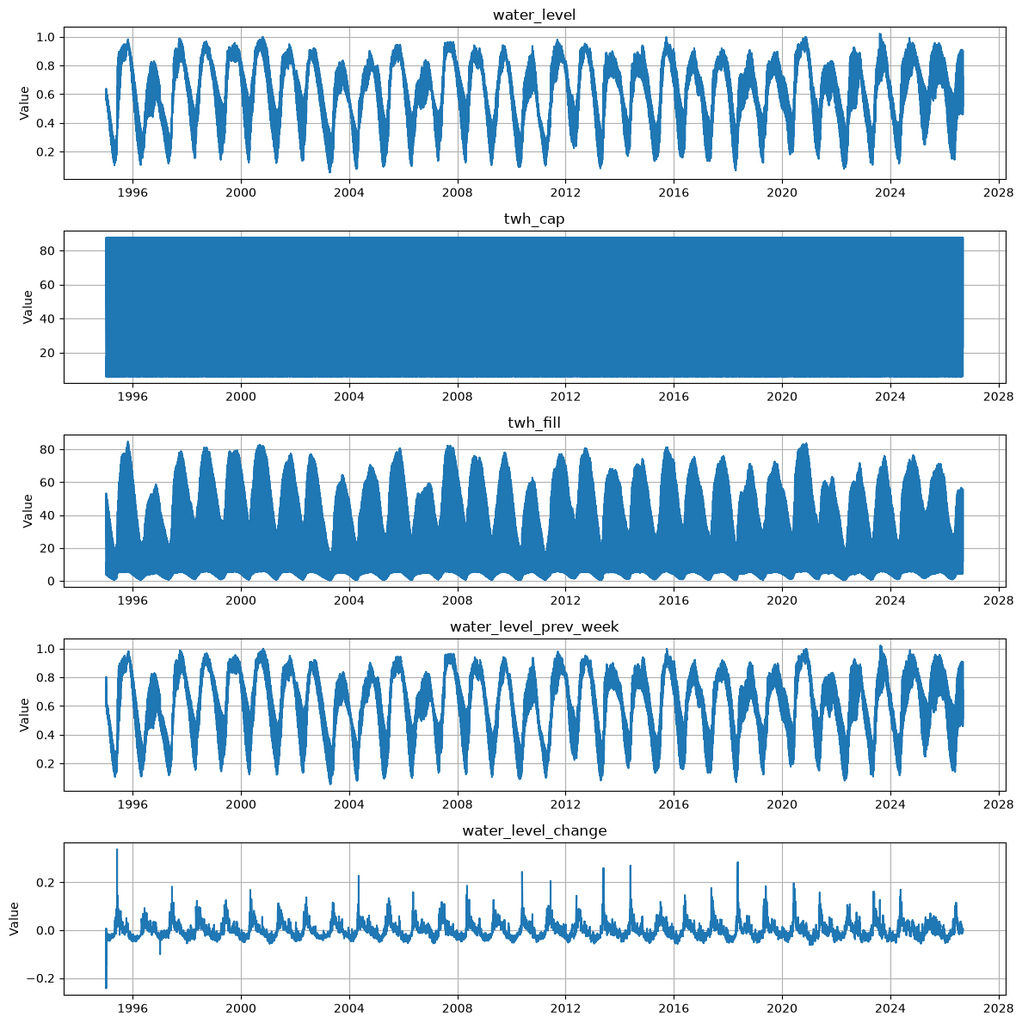

```python
# Plot each "plot-worthy" column separately - Produces unreadable plot
# Values are not normalized or aggregated by area_type / area_number

cols_to_plot = res_df_sorted.columns.drop(["date", "area_number", "area_type", "iso_year", "iso_week", "next_publication_date"]) # Exclude some non-relavant columns from plotting
num_cols = len(cols_to_plot) # Get the number of columns to plot

plt.figure(figsize=(12, 12)) # Set the figure size for the plots

# Separate subplot for each column
for i, column in enumerate(cols_to_plot):
    sub = plt.subplot(num_cols, 1, i + 1) # Create a subplot for each column

    sub.plot(res_df_sorted["date"], res_df_sorted[column], label=column)
    sub.set_title(column)
    sub.set_ylabel("Value")
    sub.grid(True)

plt.tight_layout()
plt.show()
```

```python
# Creating plotting dataframe with normalized values

plot_df: pd.DataFrame = res_df_sorted.copy() # Create a copy of the first_month DataFrame for plotting
plot_df.drop(columns=["iso_year", "iso_week", "next_publication_date"], inplace=True) # Drop columns that are not relevant for plotting

for area_number in plot_df["area_number"].unique():
    area_data: pd.DataFrame = plot_df[plot_df["area_number"] == area_number]

    # Fetch min, max for each numeric column in the area_data
    for column in area_data.select_dtypes(include="number").columns:
        if column in ["area_number"]:
            continue # Skip columns that are not relevant for normalizing

        min_val = area_data[column].min()
        max_val = area_data[column].max()
        val_range = max_val - min_val

        # Normalize to 1.0 if range is zero, otherwise use range normalized value
        normalized = (area_data[column] - min_val) / (val_range) if val_range != 0 else 1.0

        # Update the dataframe
        plot_df.loc[plot_df["area_number"] == area_number, column] = normalized

plot_df["area_type"] = plot_df["area_type"].astype('category').cat.codes # Convert 'area_type' string to numeric values use later

display(plot_df.head(7)) # Display the first few rows of the normalized plotting DataFrame
```

|  | date | area_type | area_number | water_level | twh_cap | twh_fill | water_level_prev_week | water_level_change |
| --- | --- | --- | --- | --- | --- | --- | --- | --- |
| 3468 | 1995-01-08 | 0 | 5 | 0.588217 | 1.0 | 0.588217 | 0.585778 | 0.275268 |
| 3361 | 1995-01-08 | 0 | 4 | 0.455626 | 1.0 | 0.455626 | 0.769193 | 0.000000 |
| 5036 | 1995-01-08 | 0 | 3 | 0.563810 | 0.0 | 0.168088 | 0.556582 | 0.341761 |
| 3113 | 1995-01-08 | 0 | 1 | 0.586901 | 0.0 | 0.096742 | 0.704470 | 0.098850 |
| 7739 | 1995-01-08 | 0 | 2 | 0.574835 | 1.0 | 0.592591 | 0.750852 | 0.000000 |
| 11380 | 1995-01-08 | 2 | 2 | 0.548322 | 0.0 | 0.344922 | 0.711353 | 0.043714 |
| 14162 | 1995-01-08 | 2 | 1 | 0.602001 | 1.0 | 0.642949 | 0.770735 | 0.000000 |

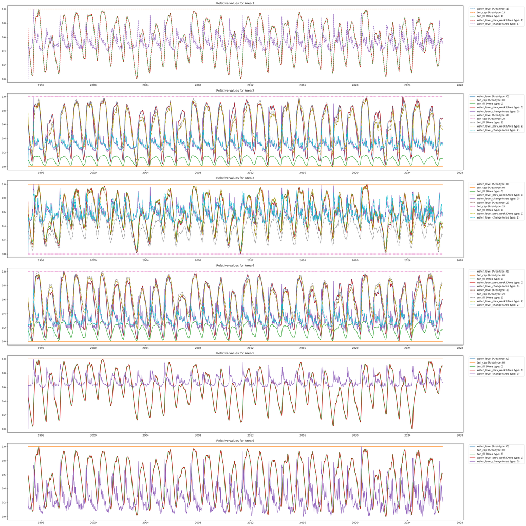

```python
# Plot all columns together. Consider how to make this natural, given that the scales are different.
# Creating one massive plot with subplots for each area_number. Each unique area_type within gets its own line style
# Still kind of unreadable due to the amount of data, but slightly better
# Each area_number and area_type deserves its own subplot

unique_line_styles = ['-', '--', '-.'] # Easier to differentiate between area types in the plots

plt.figure(figsize=(30, 30))

for area_number in plot_df["area_number"].unique(): # Separate subplots by area_number
    area_data: pd.DataFrame = plot_df[plot_df["area_number"] == area_number]

    # Create subplot for each area_number
    sub = plt.subplot(len(plot_df["area_number"].unique()), 1, area_number+1)
    sub.set_title(f"Relative values for Area {area_number+1}")

    for area_type in area_data["area_type"].unique(): # Separate by area_type within each area_number
        for column in area_data[area_data["area_type"] == area_type].select_dtypes(include="number").columns: # Column data for plotting

            if column in ["area_type", "area_number"]: # Skip columns that are not relevant for plotting
                continue

            data = area_data[area_data["area_type"] == area_type]
            sub.plot(data["date"], data[column], label=f"{column} (Area type: {area_type})",
                    linestyle=unique_line_styles[area_type]) # Plot each numeric column against date

    sub.legend(loc='upper left', bbox_to_anchor=(1.01, 1)) # Add legend to the subplot outside of plot area

plt.tight_layout()
plt.show()
```

```
Unique years (should be 1995): [1995]
Unique months (should be 1): [1]
```

|  | date | water_level | twh_cap | twh_fill | water_level_prev_week | water_level_change |
| --- | --- | --- | --- | --- | --- | --- |
| 3468 | 1995-01-08 | 0.616448 | 17.390587 | 10.720388 | 0.614288 | 0.002160 |
| 3361 | 1995-01-08 | 0.558864 | 21.079208 | 11.780413 | 0.801348 | -0.242484 |
| 5036 | 1995-01-08 | 0.602376 | 8.920932 | 5.373754 | 0.596027 | 0.006349 |
| 3113 | 1995-01-08 | 0.621467 | 6.003264 | 3.730831 | 0.734888 | -0.113421 |
| 7739 | 1995-01-08 | 0.630947 | 34.043590 | 21.479713 | 0.777604 | -0.146657 |
| 11380 | 1995-01-08 | 0.608856 | 23.237715 | 14.148431 | 0.744693 | -0.135837 |
| 14162 | 1995-01-08 | 0.636038 | 36.044464 | 22.925638 | 0.798825 | -0.162787 |

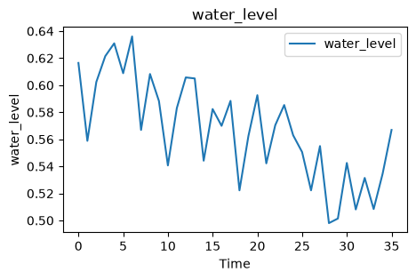

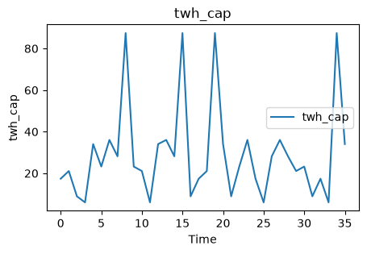

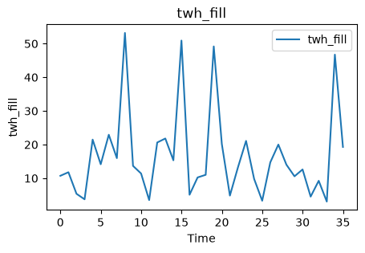

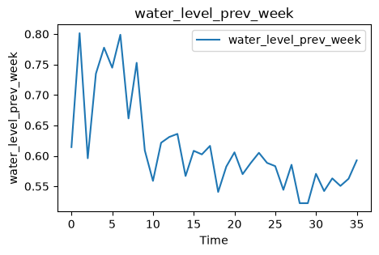

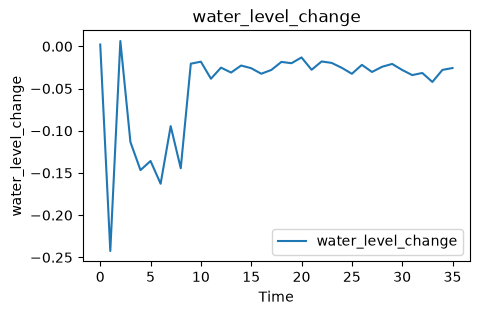

```python
# For the streamlit dashboard - Just ensuring I grab the correct data
data: pd.DataFrame = res_df_sorted.copy() # As to not modify the original DF
first_month = rd.filter_by_months(data, 1) # Get the first month of the first year
first_month.drop(columns=["area_type", "area_number", "iso_year", "iso_week", "next_publication_date"], inplace=True) # Drop columns that are not relevant for plotting

print(f"Unique years (should be 1995): {first_month["date"].dt.year.unique()}") # Sanity check - Get the unique years in the first year dataframe
print(f"Unique months (should be 1): {first_month["date"].dt.month.unique()}") # Sanity check - Get the unique months in the first month dataframe
display(first_month.head(7))

# Create a dict of col values - There should be one row in the table for each column of the imported data
col_names = first_month.select_dtypes(include="number").columns.tolist()
val_dict = {}

for col in col_names:
    val_dict[col] = first_month[col].tolist()

# Plot each separately
for col in col_names:
    plt.figure(figsize=(5, 3))
    plt.plot(val_dict[col], label=col)
    plt.xlabel("Time")
    plt.ylabel(col)
    plt.title(f"{col}")
    plt.legend()
    plt.show()
```